# HW 12: Dates

Hayley Laubinger

30 July 2020

## Load the tidyverse, here and lubridate libraries

```r
library(tidyverse)
library(here)
library(lubridate)
```

## Part 1: Play Date

```r
birth_date <- "11/25/1998"

# Elizabeth Garret Anderson was the first female physician
anderson <- "9 June 1836"

# Mary Anning discovered the first complete Plesiosaur fossil,
# and other important Jurassic fossils
anning <-  "1799/05/21"

# Alice Augusta Ball was a chemist who developed the
# first injectable treatment for leprosy.
ball <- "July 24, 1892"

# Sylvia Earle was the first chieft scientist at NOAA
earle <- "August, 30 (1935)"

# Rosalind Franklin used x-ray diffraction to
# discover DNA structure. Watson and Crick claimed credit.
franklin <- "25th of July, 1920"

# Ester Lederberg was the first to discover that viruses
# infect bacteria. Led to discovery of lambda bacteriophage
lederberg <- "December 18, 1922"

# Barbara McClintock discovered transposable elements (jumping genes),
# and developed staining techniques to study chromosomes
mcclintock <- "16061902"

# Let's also remember a dream
mlk_birth <- "1/15/1929"
mlk_dream <- "1963 August 28"
```

#### Answer the following questions using code chunks

1. Convert each date to POSIXct format, using lubridate functions, saving each to a unique variable. Print each result.

```r
birth_date <- mdy(birth_date)
birth_date
```

```
[1] "1998-11-25"
```

```r
anderson_birth_date <- dmy(anderson)
anderson_birth_date
```

```
[1] "1836-06-09"
```

```r
anning_birth_date <- ymd(anning)
anning_birth_date
```

```
[1] "1799-05-21"
```

```r
ball_birth_date <- mdy(ball)
ball_birth_date
```

```
[1] "1892-07-24"
```

```r
earle_birth_date <- mdy(earle)
earle_birth_date
```

```
[1] "1935-08-30"
```

```r
franklin_birth_date <- dmy(franklin)
franklin_birth_date
```

```
[1] "1920-07-25"
```

```r
lederberg_birth_date <- mdy(lederberg)
lederberg_birth_date
```

```
[1] "1922-12-18"
```

```r
mcclintock_birth_date <- dmy (mcclintock)
mcclintock_birth_date
```

```
[1] "1902-06-16"
```

```r
mlk_birth_date <- mdy(mlk_birth)
mlk_birth_date
```

```
[1] "1929-01-15"
```

```r
mlk_dream_date <-ymd(mlk_dream)
mlk_dream_date
```

```
[1] "1963-08-28"
```

2. Check yours dates to be sure they are correct. If you spot any errors, correct them now using the proper lubridate function(s). -All dates check out
3. What day of the week were you born on? Show the full day name, not the abbreviated name or the day number.

```r
wday(birth_date, label = TRUE, abbr = FALSE)
```

```
[1] Wednesday
7 Levels: Sunday < Monday < ... < Saturday
```

I was born on a Wednesday.

4. What day of the week will your birthday be on this year? Use lubridate’s update function. You must figure out how to do it entirely by code for full points (no hard-coding). In other words, you code should work just as well next year or five years in the future, without editing.

```r
update(birth_date, year = 2020) %>%
  weekdays(abbreviate = FALSE)
```

```
[1] "Wednesday"
```

My birthday will be on a Wednesday again.

5. What day of the week would your birthday be on in the Year 2525, if Man is still alive? How old would you be? Here you may hard-code 2525. Show the abbreviated day of the week.

```r
age <- dmy(25112525) - birth_date
as.duration(age)
```

```
[1] "16630531200s (~526.99 years)"
```

```r
update(birth_date, year = 2525) %>%
  weekdays(abbreviate = TRUE)
```

```
[1] "Sun"
```

In the year 2525, I would be 527 years old, and my birthday would be on a Sunday. Given that humans still inhabit the earth.

6. How many days was it between the birth of Dr. Elizabeth Garrett Anderson and Alice Augusta Ball?

```r
ball <- ball_birth_date - anderson_birth_date
print(ball)
```

```
Time difference of 20499 days
```

There are 20,499 days between their birth.

7. What is the duration between Martin Luther King Jr.’s birth date and his I Had a Dream speech.

```r
mlk_dream_date - mlk_birth_date
```

[output not shown]

[output not shown]

8. Enter the eight POSIXct compatible birth dates, including your own, into a vector in the order they are given above. Name each element of the vector with the last name of each person.

```r
dates <- c(birth_date, anderson_birth_date, anning_birth_date, ball_birth_date, earle_birth_date, lederberg_birth_date, mcclintock_birth_date, franklin_birth_date, mlk_birth_date)
names(dates) <- c('Laubinger','Anderson', 'Anning', 'Ball', 'Earle', 'Lederberg', 'McClintock', 'Franklin', 'King')
leap_year(dates)
```

```
 Laubinger   Anderson     Anning       Ball
     FALSE       TRUE      FALSE       TRUE
     Earle  Lederberg McClintock   Franklin
     FALSE      FALSE      FALSE       TRUE
      King
     FALSE
```

```r
difference <- dates - birth_date
print (print(difference))
```

```
Time differences in days
 Laubinger   Anderson     Anning       Ball
         0     -59338     -72871     -38839
     Earle  Lederberg McClintock   Franklin
    -23098     -27736     -35226     -28612
      King
    -25516
Time differences in days
 Laubinger   Anderson     Anning       Ball
         0     -59338     -72871     -38839
     Earle  Lederberg McClintock   Franklin
    -23098     -27736     -35226     -28612
      King
    -25516
```

## Part 2: Wrangling and plotting with dates

#### import lake_ice.csv

```r
lake_ice_data <- read_csv(here::here("data", "lake_ice.csv"),na="-999") %>%
 na.omit()
lake_ice_data
```

| lakecode | lakename | lakeorriver | season | iceon_year | iceon_month | iceon_day | iceoff_year | iceoff_month | iceoff_day | duration | latitude | longitude | country | froze | comments |
| --- | --- | --- | --- | --- | --- | --- | --- | --- | --- | --- | --- | --- | --- | --- | --- |
| ARAI1 | LAKE SUWA | L | 1944-45 | 1945 | 1 | 3 | 1945 | 3 | 28 | 80 | 36.15 | 138.08 | JAPAN | Y |  |
| ARAI1 | LAKE SUWA | L | 1945-46 | 1945 | 12 | 27 | 1946 | 3 | 6 | 76 | 36.15 | 138.08 | JAPAN | Y |  |
| ARAI1 | LAKE SUWA | L | 1946-47 | 1947 | 1 | 4 | 1947 | 3 | 12 | 68 | 36.15 | 138.08 | JAPAN | Y |  |
| ARAI1 | LAKE SUWA | L | 1947-48 | 1947 | 12 | 20 | 1948 | 2 | 27 | 70 | 36.15 | 138.08 | JAPAN | Y |  |
| ARAI1 | LAKE SUWA | L | 1949-50 | 1950 | 1 | 12 | 1950 | 1 | 31 | 33 | 36.15 | 138.08 | JAPAN | Y |  |
| ARAI1 | LAKE SUWA | L | 1950-51 | 1950 | 12 | 29 | 1951 | 2 | 25 | 59 | 36.15 | 138.08 | JAPAN | Y |  |
| ARAI1 | LAKE SUWA | L | 1951-52 | 1952 | 1 | 13 | 1952 | 3 | 27 | 75 | 36.15 | 138.08 | JAPAN | Y |  |
| ARAI1 | LAKE SUWA | L | 1952-53 | 1952 | 12 | 25 | 1953 | 3 | 4 | 57 | 36.15 | 138.08 | JAPAN | Y | preferred is date from weather station: 5 January 1953 (J.Magnuson 1 Feb 2012) |
| ARAI1 | LAKE SUWA | L | 1953-54 | 1954 | 1 | 25 | 1954 | 2 | 27 | 34 | 36.15 | 138.08 | JAPAN | Y |  |
| ARAI1 | LAKE SUWA | L | 1954-55 | 1955 | 1 | 4 | 1955 | 3 | 3 | 59 | 36.15 | 138.08 | JAPAN | Y |  |

[output cut: 990 more lines]

#### Filter data to save only Lake Mendota

```r
lake_mendota_data <- filter(lake_ice_data, lakename == "LAKE MENDOTA")
```

#### Select these six columns. You can do this in one of a few different ways but you should be able to do this very efficiently

```r
lake_mendota_data_tidy <- select(lake_mendota_data, iceon_year, iceon_month, iceon_day, iceoff_year, iceoff_month, iceoff_day) %>%
  mutate(ice_on = make_date(iceon_year, iceon_month, iceon_day) ,ice_off = make_date(iceoff_year, iceoff_month, iceoff_day), duration_days = as.numeric(ice_off-ice_on))
```

```r
lake_mendota_data_tidy
```

| iceon_year | iceon_month | iceon_day | iceoff_year | iceoff_month | iceoff_day | ice_on | ice_off | duration_days |
| --- | --- | --- | --- | --- | --- | --- | --- | --- |
| 1855 | 12 | 18 | 1856 | 4 | 14 | 1855-12-18 | 1856-04-14 | 118 |
| 1856 | 12 | 6 | 1857 | 5 | 6 | 1856-12-06 | 1857-05-06 | 151 |
| 1857 | 11 | 25 | 1858 | 3 | 26 | 1857-11-25 | 1858-03-26 | 121 |
| 1858 | 12 | 8 | 1859 | 3 | 14 | 1858-12-08 | 1859-03-14 | 96 |
| 1859 | 12 | 7 | 1860 | 3 | 26 | 1859-12-07 | 1860-03-26 | 110 |
| 1860 | 12 | 14 | 1861 | 4 | 10 | 1860-12-14 | 1861-04-10 | 117 |
| 1861 | 12 | 2 | 1862 | 4 | 13 | 1861-12-02 | 1862-04-13 | 132 |
| 1862 | 12 | 26 | 1863 | 4 | 9 | 1862-12-26 | 1863-04-09 | 104 |
| 1863 | 12 | 18 | 1864 | 4 | 21 | 1863-12-18 | 1864-04-21 | 125 |
| 1864 | 12 | 8 | 1865 | 4 | 5 | 1864-12-08 | 1865-04-05 | 118 |

[output cut: 148 more lines]

#### Make a line graph to show how duration changed over iceoff_year

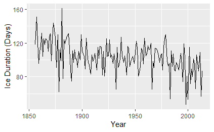

```r
ggplot(data = lake_mendota_data_tidy)+
  geom_line(mapping = aes(x=iceoff_year, y=duration_days))+xlab("Year")+ylab("Ice Duration (Days)")
```

I think this is correct. It matches the graph in the assignment.

### Soil Carbon Dioxide

#### Import Soil_co2.txt

```r
soil_data <- read_tsv(here('data', 'soil_co2.txt'))
```

```
Warning messages:
1: In readChar(file, size, TRUE) : truncating string with embedded nuls
2: In readChar(file, size, TRUE) : truncating string with embedded nuls
```

```r
soil_data
```

| DayN[] | Datecode[] | Min[] | Veg[] | Plot[] | Group[] | CorrCO2[] | SoilT[] |
| --- | --- | --- | --- | --- | --- | --- | --- |
| 481 | 1 | 0 | 1 | 6 | 1 | 398.18 | 291.1 |
| 481 | 1 | 15 | 1 | 6 | 1 | 510.06 | 291.1 |
| 481 | 1 | 30 | 1 | 6 | 1 | 499.62 | 291.1 |
| 481 | 1 | 0 | 1 | 18 | 2 | 474.52 | 290.8 |
| 481 | 1 | 15 | 1 | 18 | 2 | 674.17 | 290.8 |
| 481 | 1 | 30 | 1 | 18 | 2 | 763.96 | 290.8 |
| 481 | 1 | 0 | 1 | 14 | 3 | 801.90 | 289.3 |
| 481 | 1 | 15 | 1 | 14 | 3 | 764.36 | 289.3 |
| 481 | 1 | 30 | 1 | 14 | 3 | 830.51 | 289.3 |
| 481 | 1 | 0 | 1 | 10 | 4 | 404.05 | 290.8 |

[output cut: 990 more lines]

Appears to be imported correctly

#### Establish a POSIXct-compatible date variable for 01 January 2006.

```r
soil_date <- dmy('01 January 2006')
```

```r
soil_date
```

```
[1] "2006-01-01"
```

#### Rename the columns so that they are syntactic.Make a Date column that adds the day of CO2 measurement to the 01 Jan 2006 reference date.Create a Year column, create a month column, group data by year and month.Summarize mean CO2 and standard error of the mean.

```r
soil_co2_data <- soil_data %>%
  rename("Day" = "DayN[]", "Date_code" = "Datecode[]",  "Min" = "Min[]", "Veg" = "Veg[]", "Plot" = "Plot[]", "Group" = "Group[]", "Corr_CO2" = "CorrCO2[]", "Soil_T" =  "SoilT[]") %>%
  mutate(Date=soil_date+Day,
         Year=year(Date),
         Month=month(Date,label=TRUE))
soil_co2_data
```

| Day | Date_code | Min | Veg | Plot | Group | Corr_CO2 | Soil_T | Date | Year | Month |
| --- | --- | --- | --- | --- | --- | --- | --- | --- | --- | --- |
| 481 | 1 | 0 | 1 | 6 | 1 | 398.18 | 291.1 | 2007-04-27 | 2007 | Apr |
| 481 | 1 | 15 | 1 | 6 | 1 | 510.06 | 291.1 | 2007-04-27 | 2007 | Apr |
| 481 | 1 | 30 | 1 | 6 | 1 | 499.62 | 291.1 | 2007-04-27 | 2007 | Apr |
| 481 | 1 | 0 | 1 | 18 | 2 | 474.52 | 290.8 | 2007-04-27 | 2007 | Apr |
| 481 | 1 | 15 | 1 | 18 | 2 | 674.17 | 290.8 | 2007-04-27 | 2007 | Apr |
| 481 | 1 | 30 | 1 | 18 | 2 | 763.96 | 290.8 | 2007-04-27 | 2007 | Apr |
| 481 | 1 | 0 | 1 | 14 | 3 | 801.90 | 289.3 | 2007-04-27 | 2007 | Apr |
| 481 | 1 | 15 | 1 | 14 | 3 | 764.36 | 289.3 | 2007-04-27 | 2007 | Apr |
| 481 | 1 | 30 | 1 | 14 | 3 | 830.51 | 289.3 | 2007-04-27 | 2007 | Apr |
| 481 | 1 | 0 | 1 | 10 | 4 | 404.05 | 290.8 | 2007-04-27 | 2007 | Apr |

[output cut: 990 more lines]

```r
soil_data_grouped <- group_by (soil_co2_data, Year,Month)
soil_data_summarized <- summarise( soil_data_grouped,meanCO2=mean(Corr_CO2,na.rm = TRUE),std_err_CO2=std_err(Corr_CO2,na.rm=TRUE),.groups = 'drop')
soil_data_summarized
```

| Year | Month | meanCO2 | std_err_CO2 |
| --- | --- | --- | --- |
| 2007 | Apr | 610.3469 | 18.16704 |
| 2007 | May | 878.8084 | 16.55794 |
| 2007 | Jun | 1039.9411 | 25.53794 |
| 2007 | Jul | 970.0604 | 31.19578 |
| 2007 | Aug | 1115.6591 | 53.41010 |
| 2007 | Sep | 1004.7191 | 30.35294 |
| 2007 | Oct | 686.1444 | 14.27253 |
| 2008 | Apr | 640.8884 | 12.27243 |
| 2008 | May | 961.0424 | 32.14498 |
| 2008 | Jun | 1151.2460 | 36.37925 |

[output cut: 26 more lines]

#### Make a column chart of mean CO2 for each month.

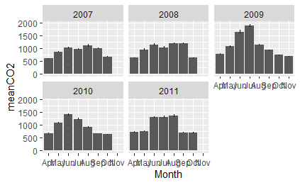

```r
ggplot(data=soil_data_summarized)+
   geom_col(mapping=aes(x=Month,y=meanCO2))+
  geom_linerange(aes(x=Month,ymin=meanCO2-std_err_CO2,ymax=meanCO2+std_err_CO2))+
facet_wrap(~Year)
```

This seems to match the graphs on the assignment.They are the correct height and appropriate axis labels.

#### Make the same plot but use points instead of columns, and use only geom_linerange

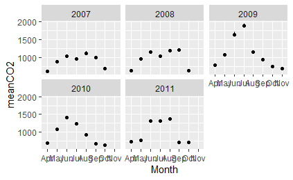

```r
  ggplot(data=soil_data_summarized)+
   geom_point(mapping=aes(x=Month,y=meanCO2))+
  geom_linerange(aes(x=Month,ymin=meanCO2-std_err_CO2,ymax=meanCO2+std_err_CO2))+
facet_wrap(~Year)
```

Again, the data matches that of the assignment.

### Mississippi River Discharge

#### Import and tidy data

```r
thebes_data <- read_csv(here('data', 'thebes_discharge.csv'))
thebes_data
```

| Month | Day | 1988 | 1989 | 1990 | 1991 | 1992 | 1993 | 1994 | 1995 | 1996 | 1997 | 1998 | 1999 | 2000 | 2001 | 2002 | 2003 | 2004 | 2005 | 2006 | 2007 | 2008 | 2009 | 2010 | 2011 | 2012 | 2013 | 2014 | 2015 | … |
| --- | --- | --- | --- | --- | --- | --- | --- | --- | --- | --- | --- | --- | --- | --- | --- | --- | --- | --- | --- | --- | --- | --- | --- | --- | --- | --- | --- | --- | --- | --- |
| 1 | 1 | 371000 | 134000 | 54500 | 256000 | 205000 | 279000 | 143000 | 135000 | 108000 | 132000 | 160000 | 115000 | 82400 | 77100 | 99600 | 107000 | 133000 | 129000 | 93000 | 161000 | 150000 | 418000 | 436000 | 146000 | 169000 | 68000 | 104000 | 165000 | … |
| 1 | 2 | 329000 | 128000 | 54600 | 254000 | 188000 | 286000 | 149000 | 129000 | 109000 | 140000 | 150000 | 115000 | 86400 | 76200 | 104000 | 109000 | 134000 | 128000 | 92800 | 162000 | 147000 | 408000 | 395000 | 171000 | 166000 | 66900 | 99300 | 156000 | … |
| 1 | 3 | 283000 | 118000 | 54600 | 247000 | 182000 | 286000 | 155000 | 126000 | 109000 | 141000 | 146000 | 119000 | 101000 | 77000 | 101000 | 113000 | 141000 | 128000 | 93400 | 158000 | 137000 | 383000 | 327000 | 205000 | 163000 | 65900 | 99200 | 150000 | … |
| 1 | 4 | 240000 | 115000 | 58600 | 240000 | 175000 | 286000 | 156000 | 119000 | 109000 | 142000 | 144000 | 113000 | 114000 | 77400 | 96200 | 113000 | 142000 | 143000 | 95100 | 155000 | 121000 | 353000 | 265000 | 209000 | 153000 | 65600 | 98400 | 144000 | … |
| 1 | 5 | 211000 | 110000 | 64800 | 217000 | 166000 | 342000 | 154000 | 108000 | 104000 | 142000 | 144000 | 111000 | 113000 | 76700 | 94000 | 108000 | 156000 | 230000 | 99300 | 158000 | 115000 | 327000 | 242000 | 200000 | 146000 | 66700 | 93400 | 141000 | … |
| 1 | 6 | 191000 | 111000 | 66800 | 196000 | 161000 | 435000 | 148000 | 97500 | 99600 | 140000 | 161000 | 112000 | 110000 | 77700 | 94200 | 103000 | 183000 | 425000 | 104000 | 166000 | 123000 | 305000 | 228000 | 202000 | 146000 | 67000 | 91800 | 148000 | … |
| 1 | 7 | 175000 | 125000 | 65800 | 194000 | 155000 | 458000 | 147000 | 91900 | 96700 | 136000 | 194000 | 114000 | 103000 | 79600 | 97700 | 99600 | 193000 | 519000 | 105000 | 172000 | 134000 | 277000 | 232000 | 204000 | 136000 | 66400 | 86800 | 144000 | … |
| 1 | 8 | 167000 | 144000 | 65400 | 184000 | 158000 | 465000 | 154000 | 93500 | 92100 | 136000 | 230000 | 121000 | 102000 | 79600 | 99500 | 97900 | 179000 | 534000 | 103000 | 179000 | 143000 | 253000 | 235000 | 203000 | 129000 | 65700 | 83700 | 131000 | … |
| 1 | 9 | 160000 | 143000 | 67100 | 173000 | 161000 | 456000 | 150000 | 96100 | 90700 | 133000 | 295000 | 120000 | 98600 | 80200 | 98500 | 95000 | 159000 | 500000 | 103000 | 186000 | 160000 | 244000 | 221000 | 199000 | 122000 | 65100 | 82500 | 121000 | … |
| 1 | 10 | 153000 | 123000 | 68200 | 165000 | 163000 | 424000 | 147000 | 96800 | 90300 | 133000 | 345000 | 112000 | 94900 | 80400 | 101000 | 92600 | 144000 | 465000 | 107000 | 187000 | 213000 | 236000 | 211000 | 181000 | 115000 | 65000 | 81400 | 112000 | … |

[output cut: 356 more lines]

```r
thebes_data_tidy<- thebes_data %>%
  pivot_longer(c('1988':'2018'), names_to = 'year', values_to = 'discharge')
thebes_data_tidy
```

| Month | Day | year | discharge |
| --- | --- | --- | --- |
| 1 | 1 | 1988 | 371000 |
| 1 | 1 | 1989 | 134000 |
| 1 | 1 | 1990 | 54500 |
| 1 | 1 | 1991 | 256000 |
| 1 | 1 | 1992 | 205000 |
| 1 | 1 | 1993 | 279000 |
| 1 | 1 | 1994 | 143000 |
| 1 | 1 | 1995 | 135000 |
| 1 | 1 | 1996 | 108000 |
| 1 | 1 | 1997 | 132000 |

[output cut: 990 more lines]

#### dividing the discharge by 1000 to improve interpretation of the y-axis

```r
thebes_divided_discharge <- thebes_data_tidy %>%
  mutate(discharge = discharge / 1000)
thebes_divided_discharge
```

| Month | Day | year | discharge |
| --- | --- | --- | --- |
| 1 | 1 | 1988 | 371.0 |
| 1 | 1 | 1989 | 134.0 |
| 1 | 1 | 1990 | 54.5 |
| 1 | 1 | 1991 | 256.0 |
| 1 | 1 | 1992 | 205.0 |
| 1 | 1 | 1993 | 279.0 |
| 1 | 1 | 1994 | 143.0 |
| 1 | 1 | 1995 | 135.0 |
| 1 | 1 | 1996 | 108.0 |
| 1 | 1 | 1997 | 132.0 |

[output cut: 990 more lines]

Adding thebes_divided_discharge, allowed for the discharge column data to be shown. Mistakes caused no data to be in that column.

#### Group by year and month, and summmarize mean discharge. Add an Event column using mutate and case_when.

```r
thebes_grouped_data <- thebes_divided_discharge %>%
  group_by(year, Month)
thebes_grouped_data
```

| Month | Day | year | discharge |
| --- | --- | --- | --- |
| 1 | 1 | 1988 | 371.0 |
| 1 | 1 | 1989 | 134.0 |
| 1 | 1 | 1990 | 54.5 |
| 1 | 1 | 1991 | 256.0 |
| 1 | 1 | 1992 | 205.0 |
| 1 | 1 | 1993 | 279.0 |
| 1 | 1 | 1994 | 143.0 |
| 1 | 1 | 1995 | 135.0 |
| 1 | 1 | 1996 | 108.0 |
| 1 | 1 | 1997 | 132.0 |

[output cut: 990 more lines]

```r
thebes_summarized_data <-thebes_grouped_data %>%
  summarize(
    mean_discharge = mean(discharge)
  )
thebes_summarized_data
```

| year | Month | mean_discharge |
| --- | --- | --- |
| 1988 | 1 | 189.38710 |
| 1988 | 2 | 211.20690 |
| 1988 | 3 | 211.19355 |
| 1988 | 4 | 266.76667 |
| 1988 | 5 | 140.06452 |
| 1988 | 6 | 83.85667 |
| 1988 | 7 | 73.60000 |
| 1988 | 8 | 71.63871 |
| 1988 | 9 | 75.86000 |
| 1988 | 10 | 76.96452 |

[output cut: 362 more lines]

```r
thebes_event <- thebes_summarized_data %>%
  mutate(
    event = case_when(
      year == '1993' ~ 'Flood' ,
      year == '2011' ~ 'Flood',
      year == '1988' ~ 'Drought',
      year == '2012' ~ 'Drought',
      TRUE ~ 'Normal'
    )
  )
thebes_event
```

| year | Month | mean_discharge | event |
| --- | --- | --- | --- |
| 1988 | 1 | 189.38710 | Drought |
| 1988 | 2 | 211.20690 | Drought |
| 1988 | 3 | 211.19355 | Drought |
| 1988 | 4 | 266.76667 | Drought |
| 1988 | 5 | 140.06452 | Drought |
| 1988 | 6 | 83.85667 | Drought |
| 1988 | 7 | 73.60000 | Drought |
| 1988 | 8 | 71.63871 | Drought |
| 1988 | 9 | 75.86000 | Drought |
| 1988 | 10 | 76.96452 | Drought |

[output cut: 362 more lines]

Finally was able to get mean_discharge data to show. Had to break code apart to view mistakes. Added events to the remaining two years

#### Make second data set

```r
thebes_event <- thebes_summarized_data %>%
  filter(year%in%c(1988,1993, 2011, 2012))
thebes_event
```

| year | Month | mean_discharge |
| --- | --- | --- |
| 1988 | 1 | 189.38710 |
| 1988 | 2 | 211.20690 |
| 1988 | 3 | 211.19355 |
| 1988 | 4 | 266.76667 |
| 1988 | 5 | 140.06452 |
| 1988 | 6 | 83.85667 |
| 1988 | 7 | 73.60000 |
| 1988 | 8 | 71.63871 |
| 1988 | 9 | 75.86000 |
| 1988 | 10 | 76.96452 |

[output cut: 38 more lines]

Adding %in% allowed for rows to be created, when prior I had 0 rows created. year== adds error, so remove and add year in front of %in%.

#### Plot data

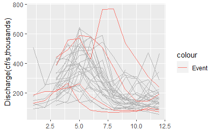

```r
ggplot(data=thebes_summarized_data)+
  geom_line(mapping=aes(x=Month,y=mean_discharge,group=year),color="grey70",size=0.3)+
  geom_line(thebes_event,mapping = aes(Month,mean_discharge,group=year,color="Event"))+
labs(x=NULL,
     y="Discharge(cf/s,thousands)")
```

The graph looks similar to the notes, but lacks the event key, with each event in separate colors. I am having issues having the key labeled “Events” and having the correct events in the key.